# 📊 PROYECTO 2 — ANÁLISIS DE VENTAS

📈 Análisis Exploratorio de Datos

## 🎯 Objetivo del proyecto

El objetivo de este proyecto es analizar un conjunto de datos de ventas para identificar patrones, tendencias y oportunidades de mejora en el desempeño comercial del negocio.

A través de Python, Pandas y visualizaciones, se realizará un análisis de las ventas, ganancias, productos, ciudades y comportamiento de las ventas a lo largo del tiempo.

## 🔎 ¿Qué se analizará?

🧹 Limpieza y preparación de los datos

💰 Ventas y ganancias

📦 Rendimiento de los productos

🏆 Productos más rentables

🏙️ Ganancias por ciudad

📅 Evolución de las ventas en el tiempo

📊 Visualización de resultados

🔎 Hallazgos principales

📝 Conclusiones finales

🛠️ Herramientas utilizadas

Python · Pandas · Matplotlib · Jupyter Notebook

# jhonnattan monroy

## Proyecto de práctica — Análisis de Datos

Del dato a la información, y de la información a mejores decisiones. 📊

# 📌 Ficha del proyecto

Elemento

Información

Proyecto

# Proyecto 2 — Análisis de Ventas

Tipo de análisis

Análisis Exploratorio de Datos (EDA)

Lenguaje

Python

Librerías principales

Pandas y Matplotlib

Entorno

Jupyter Notebook

Enfoque

Ventas, ganancias, productos, ciudades y tendencias

# 📌 Resultado esperado

Convertir los datos de ventas en información útil que permita comprender el comportamiento del negocio y apoyar la toma de decisiones.

```python
import pandas as pd
import numpy as np

np.random.seed(42)
```

```python
productos = {
    "Laptop": "Computadores",
    "PC Escritorio": "Computadores",
    "Monitor": "Computadores",
    "Mouse": "Perifericos",
    "Teclado": "Perifericos",
    "Cámara Web": "Perifericos",
    "Memoria RAM": "Componentes",
    "Disco SSD": "Almacenamiento",
    "Router": "Redes",
    "Impresora": "Impresión"
}
```

```python
precios = {
    "Laptop": 2500000,
    "PC Escritorio": 1800000,
    "Monitor": 850000,
    "Mouse": 45000,
    "Teclado": 85000,
    "Cámara Web": 160000,
    "Memoria RAM": 220000,
    "Disco SSD": 280000,
    "Router": 180000,
    "Impresora": 750000
}
```

# 1. 📂 Carga y exploración de los datos

```python
costos = {
    "Laptop": 1900000,
    "PC Escritorio": 1350000,
    "Monitor": 650000,
    "Mouse": 30000,
    "Teclado": 55000,
    "Cámara Web": 105000,
    "Memoria RAM": 150000,
    "Disco SSD": 190000,
    "Router": 120000,
    "Impresora": 560000
}

ciudades = ["Bogotá", "Medellín", "Cali", "Barranquilla", "Tunja"]

vendedores = [
    "Carlos", "Laura", "Andrés", "Camila", "Miguel"
]

metodos_pago = [
    "Efectivo", "Tarjeta", "Transferencia", "Nequi"
]
n = 100

producto = np.random.choice(list(productos.keys()), n)

df_ventas = pd.DataFrame({
    "Fecha": pd.date_range(
        start="2026-01-01",
        end="2026-07-31",
        periods=n
    ),
    "Producto": producto,
    "Categoria": [productos[p] for p in producto],
    "Ciudad": np.random.choice(ciudades, n),
    "Vendedor": np.random.choice(vendedores, n),
    "Metodo_Pago": np.random.choice(metodos_pago, n),
    "Cantidad": np.random.randint(1, 11, n),
    "Precio": [precios[p] for p in producto],
    "Costo": [costos[p] for p in producto]
})

df_ventas["Venta_Total"] = (
    df_ventas["Cantidad"] * df_ventas["Precio"]
)

df_ventas["Costo_Total"] = (
    df_ventas["Cantidad"] * df_ventas["Costo"]
)

df_ventas["Ganancia"] = (
    df_ventas["Venta_Total"] - df_ventas["Costo_Total"]
)

df_ventas["Margen_%"] = (
    df_ventas["Ganancia"] / df_ventas["Venta_Total"] * 100
)
print("Dataset creado correctamente.")
print(f"Cantidad de registros: {len(df_ventas)}")
print(f"Cantidad de columnas: {len(df_ventas.columns)}")

display(df_ventas.head(10))
```

```
Dataset creado correctamente.
Cantidad de registros: 100
Cantidad de columnas: 13
```

|  | Fecha | Producto | Categoria | Ciudad | Vendedor | Metodo_Pago | Cantidad | Precio | Costo | Venta_Total | Costo_Total | Ganancia | Margen_% |
| --- | --- | --- | --- | --- | --- | --- | --- | --- | --- | --- | --- | --- | --- |
| 0 | 2026-01-01 00:00:00.000000000 | Memoria RAM | Componentes | Barranquilla | Carlos | Efectivo | 5 | 220000 | 150000 | 1100000 | 750000 | 350000 | 31.818182 |
| 1 | 2026-01-03 03:09:05.454545454 | Mouse | Perifericos | Medellín | Carlos | Tarjeta | 5 | 45000 | 30000 | 225000 | 150000 | 75000 | 33.333333 |
| 2 | 2026-01-05 06:18:10.909090909 | Disco SSD | Almacenamiento | Bogotá | Camila | Efectivo | 7 | 280000 | 190000 | 1960000 | 1330000 | 630000 | 32.142857 |
| 3 | 2026-01-07 09:27:16.363636363 | Teclado | Perifericos | Tunja | Andrés | Transferencia | 4 | 85000 | 55000 | 340000 | 220000 | 120000 | 35.294118 |
| 4 | 2026-01-09 12:36:21.818181818 | Memoria RAM | Componentes | Cali | Miguel | Transferencia | 6 | 220000 | 150000 | 1320000 | 900000 | 420000 | 31.818182 |
| 5 | 2026-01-11 15:45:27.272727272 | Impresora | Impresión | Barranquilla | Andrés | Nequi | 4 | 750000 | 560000 | 3000000 | 2240000 | 760000 | 25.333333 |
| 6 | 2026-01-13 18:54:32.727272727 | Monitor | Computadores | Cali | Camila | Efectivo | 3 | 850000 | 650000 | 2550000 | 1950000 | 600000 | 23.529412 |
| 7 | 2026-01-15 22:03:38.181818181 | Memoria RAM | Componentes | Cali | Camila | Nequi | 7 | 220000 | 150000 | 1540000 | 1050000 | 490000 | 31.818182 |
| 8 | 2026-01-18 01:12:43.636363636 | Disco SSD | Almacenamiento | Bogotá | Andrés | Transferencia | 8 | 280000 | 190000 | 2240000 | 1520000 | 720000 | 32.142857 |
| 9 | 2026-01-20 04:21:49.090909090 | Teclado | Perifericos | Cali | Camila | Efectivo | 4 | 85000 | 55000 | 340000 | 220000 | 120000 | 35.294118 |

# 2. 🧹 Limpieza y preparación de los datos

```python
print("===== DIMENSIONES =====")
print(f"Filas: {df_ventas.shape[0]}")
print(f"Columnas: {df_ventas.shape[1]}")

print("\n===== TIPOS DE DATOS =====")
print(df_ventas.dtypes)

print("\n===== VALORES NULOS =====")
print(df_ventas.isnull().sum())

print("\n===== REGISTROS DUPLICADOS =====")
print(df_ventas.duplicated().sum())

print("\n===== ESTADÍSTICAS NUMÉRICAS =====")
display(df_ventas.describe())
```

```
===== DIMENSIONES =====
Filas: 100
Columnas: 13

===== TIPOS DE DATOS =====
Fecha          datetime64[ns]
Producto               object
Categoria              object
Ciudad                 object
Vendedor               object
Metodo_Pago            object
Cantidad                int32
Precio                  int64
Costo                   int64
Venta_Total             int64
Costo_Total             int64
Ganancia                int64
Margen_%              float64
dtype: object

===== VALORES NULOS =====
Fecha          0
Producto       0
Categoria      0
Ciudad         0
Vendedor       0
Metodo_Pago    0
Cantidad       0
Precio         0
Costo          0
Venta_Total    0
Costo_Total    0
Ganancia       0
Margen_%       0
dtype: int64

===== REGISTROS DUPLICADOS =====
0

===== ESTADÍSTICAS NUMÉRICAS =====
```

|  | Fecha | Cantidad | Precio | Costo | Venta_Total | Costo_Total | Ganancia | Margen_% |
| --- | --- | --- | --- | --- | --- | --- | --- | --- |
| count | 100 | 100.000000 | 1.000000e+02 | 1.000000e+02 | 1.000000e+02 | 1.000000e+02 | 1.000000e+02 | 100.000000 |
| mean | 2026-04-16 12:00:00.000000256 | 5.520000 | 6.239500e+05 | 4.620000e+05 | 3.274050e+06 | 2.416700e+06 | 8.573500e+05 | 29.997654 |
| min | 2026-01-01 00:00:00 | 1.000000 | 4.500000e+04 | 3.000000e+04 | 9.000000e+04 | 6.000000e+04 | 3.000000e+04 | 23.529412 |
| 25% | 2026-02-22 18:00:00 | 3.000000 | 1.750000e+05 | 1.162500e+05 | 5.862500e+05 | 3.837500e+05 | 1.875000e+05 | 25.000000 |
| 50% | 2026-04-16 12:00:00 | 5.000000 | 2.800000e+05 | 1.900000e+05 | 1.440000e+06 | 9.600000e+05 | 4.800000e+05 | 32.142857 |
| 75% | 2026-06-08 06:00:00 | 8.000000 | 8.500000e+05 | 6.500000e+05 | 3.875000e+06 | 2.912500e+06 | 9.625000e+05 | 33.333333 |
| max | 2026-07-31 00:00:00 | 10.000000 | 2.500000e+06 | 1.900000e+06 | 2.000000e+07 | 1.520000e+07 | 4.800000e+06 | 35.294118 |
| std | NaN | 3.076401 | 7.264826e+05 | 5.547681e+05 | 4.342494e+06 | 3.296178e+06 | 1.049198e+06 | 4.325245 |

```python
ventas_totales = df_ventas["Venta_Total"].sum()
ganancia_total = df_ventas["Ganancia"].sum()
unidades_vendidas = df_ventas["Cantidad"].sum()
numero_transacciones = len(df_ventas)

ticket_promedio = ventas_totales / numero_transacciones
margen_global = (ganancia_total / ventas_totales) * 100

print("========== KPIs COMERCIALES ==========")
print(f"Ventas totales:        ${ventas_totales:,.0f}")
print(f"Ganancia total:        ${ganancia_total:,.0f}")
print(f"Unidades vendidas:     {unidades_vendidas:,}")
print(f"Número de ventas:      {numero_transacciones:,}")
print(f"Ticket promedio:       ${ticket_promedio:,.0f}")
print(f"Margen global:         {margen_global:.2f}%")
```

```
========== KPIs COMERCIALES ==========
Ventas totales:        $327,405,000
Ganancia total:        $85,735,000
Unidades vendidas:     552
Número de ventas:      100
Ticket promedio:       $3,274,050
Margen global:         26.19%
```

```python
rentabilidad_producto = (
    df_ventas.groupby("Producto")
    .agg(
        Ventas_Totales=("Venta_Total", "sum"),
        Ganancia_Total=("Ganancia", "sum"),
        Unidades_Vendidas=("Cantidad", "sum")
    )
    .sort_values("Ganancia_Total", ascending=False)
)

rentabilidad_producto["Margen_%"] = (
    rentabilidad_producto["Ganancia_Total"]
    / rentabilidad_producto["Ventas_Totales"] * 100
)

display(rentabilidad_producto)
```

| Producto | Ventas_Totales | Ganancia_Total | Unidades_Vendidas | Margen_% |
| --- | --- | --- | --- | --- |
| PC Escritorio | 102600000 | 25650000 | 57 | 25.000000 |
| Laptop | 70000000 | 16800000 | 28 | 24.000000 |
| Impresora | 54750000 | 13870000 | 73 | 25.333333 |
| Monitor | 37400000 | 8800000 | 44 | 23.529412 |
| Disco SSD | 25200000 | 8100000 | 90 | 32.142857 |
| Router | 13320000 | 4440000 | 74 | 33.333333 |
| Memoria RAM | 9680000 | 3080000 | 44 | 31.818182 |
| Cámara Web | 8160000 | 2805000 | 51 | 34.375000 |
| Teclado | 4675000 | 1650000 | 55 | 35.294118 |
| Mouse | 1620000 | 540000 | 36 | 33.333333 |

```python
producto_mas_rentable = rentabilidad_producto["Ganancia_Total"].idxmax()
ganancia_mas_alta = rentabilidad_producto["Ganancia_Total"].max()


producto_mayor_margen = rentabilidad_producto["Margen_%"].idxmax()
margen_mas_alto = rentabilidad_producto["Margen_%"].max()


producto_mas_vendido = rentabilidad_producto["Ventas_Totales"].idxmax()
ventas_mas_altas = rentabilidad_producto["Ventas_Totales"].max()

print("========== PRODUCTOS DESTACADOS ==========")

print(
    f"🏆 Mayor ganancia: {producto_mas_rentable} "
    f"(${ganancia_mas_alta:,.0f})"
)

print(
    f"📈 Mayor margen: {producto_mayor_margen} "
    f"({margen_mas_alto:.2f}%)"
)

print(
    f"💰 Mayores ventas: {producto_mas_vendido} "
    f"(${ventas_mas_altas:,.0f})"
)
```

```
========== PRODUCTOS DESTACADOS ==========
🏆 Mayor ganancia: PC Escritorio ($25,650,000)
📈 Mayor margen: Teclado (35.29%)
💰 Mayores ventas: PC Escritorio ($102,600,000)
```

```python
df_ventas["Mes"] = df_ventas["Fecha"].dt.to_period("M")

ventas_mensuales = (
    df_ventas.groupby("Mes")
    .agg(
        Ventas=("Venta_Total", "sum"),
        Ganancia=("Ganancia", "sum"),
        Unidades=("Cantidad", "sum"),
        Transacciones=("Producto", "count")
    )
)
ventas_mensuales["Crecimiento_%"] = (
    ventas_mensuales["Ventas"].pct_change() * 100
)
display(ventas_mensuales)
```

| Mes | Ventas | Ganancia | Unidades | Transacciones | Crecimiento_% |
| --- | --- | --- | --- | --- | --- |
| 2026-01 | 20475000 | 6125000 | 77 | 15 | NaN |
| 2026-02 | 70255000 | 17945000 | 92 | 13 | 243.125763 |
| 2026-03 | 40690000 | 10595000 | 78 | 15 | -42.082414 |
| 2026-04 | 55755000 | 14200000 | 79 | 14 | 37.023839 |
| 2026-05 | 46660000 | 12540000 | 88 | 14 | -16.312438 |
| 2026-06 | 38925000 | 10070000 | 52 | 14 | -16.577368 |
| 2026-07 | 54645000 | 14260000 | 86 | 15 | 40.385356 |

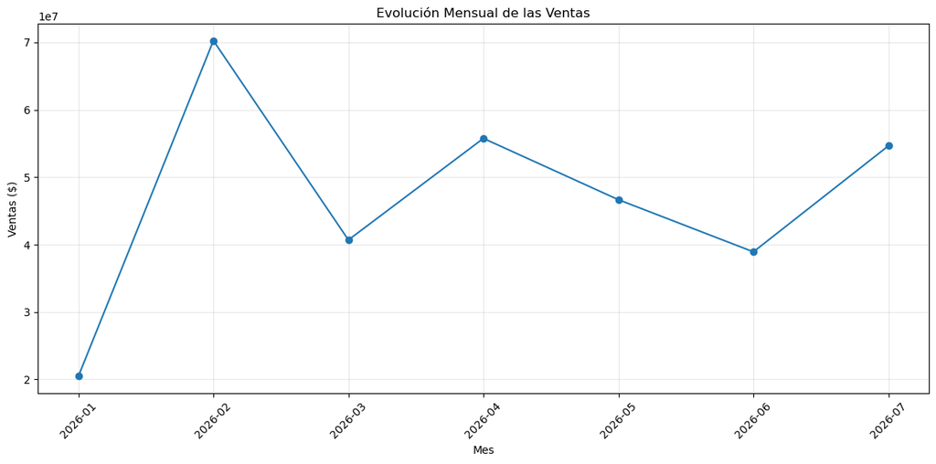

```python
import matplotlib.pyplot as plt

plt.figure(figsize=(12, 6))

plt.plot(
    ventas_mensuales.index.astype(str),
    ventas_mensuales["Ventas"],
    marker="o"
)
plt.title("Evolución Mensual de las Ventas")
plt.xlabel("Mes")
plt.ylabel("Ventas ($)")
plt.xticks(rotation=45)
plt.grid(True, alpha=0.3)

plt.tight_layout()
plt.show()
```

```python
mejor_mes = ventas_mensuales["Ventas"].idxmax()
ventas_mejor_mes = ventas_mensuales.loc[mejor_mes, "Ventas"]

peor_mes = ventas_mensuales["Ventas"].idxmin()
ventas_peor_mes = ventas_mensuales.loc[peor_mes, "Ventas"]

mejor_crecimiento = ventas_mensuales["Crecimiento_%"].idxmax()
peor_crecimiento = ventas_mensuales["Crecimiento_%"].idxmin()

print("========== ANÁLISIS MENSUAL ==========")

print(f"🏆 Mejor mes en ventas: {mejor_mes}")
print(f"   Ventas: ${ventas_mejor_mes:,.0f}")

print(f"\n📉 Peor mes en ventas: {peor_mes}")
print(f"   Ventas: ${ventas_peor_mes:,.0f}")

print(f"\n📈 Mayor crecimiento mensual: {mejor_crecimiento}")
print(
    f"   Crecimiento: "
    f"{ventas_mensuales.loc[mejor_crecimiento, 'Crecimiento_%']:.2f}%"
)

print(f"\n⚠️ Mayor caída mensual: {peor_crecimiento}")
print(
    f"   Variación: "
    f"{ventas_mensuales.loc[peor_crecimiento, 'Crecimiento_%']:.2f}%"
)
```

```
========== ANÁLISIS MENSUAL ==========
🏆 Mejor mes en ventas: 2026-02
   Ventas: $70,255,000

📉 Peor mes en ventas: 2026-01
   Ventas: $20,475,000

📈 Mayor crecimiento mensual: 2026-02
   Crecimiento: 243.13%

⚠️ Mayor caída mensual: 2026-03
   Variación: -42.08%
```

```python
analisis_ciudad = (
    df_ventas.groupby("Ciudad")
    .agg(
        Ventas_Totales=("Venta_Total", "sum"),
        Ganancia_Total=("Ganancia", "sum"),
        Unidades_Vendidas=("Cantidad", "sum"),
        Transacciones=("Producto", "count")
    )
    .sort_values("Ventas_Totales", ascending=False)
)

analisis_ciudad["Margen_%"] = (
    analisis_ciudad["Ganancia_Total"]
    / analisis_ciudad["Ventas_Totales"] * 100
)

display(analisis_ciudad)
```

| Ciudad | Ventas_Totales | Ganancia_Total | Unidades_Vendidas | Transacciones | Margen_% |
| --- | --- | --- | --- | --- | --- |
| Bogotá | 108565000 | 27885000 | 129 | 24 | 25.685073 |
| Barranquilla | 90625000 | 23515000 | 122 | 22 | 25.947586 |
| Cali | 70865000 | 18545000 | 127 | 22 | 26.169477 |
| Tunja | 33375000 | 8685000 | 89 | 17 | 26.022472 |
| Medellín | 23975000 | 7105000 | 85 | 15 | 29.635036 |

```python
analisis_vendedor = (
    df_ventas.groupby("Vendedor")
    .agg(
        Ventas_Totales=("Venta_Total", "sum"),
        Ganancia_Total=("Ganancia", "sum"),
        Unidades_Vendidas=("Cantidad", "sum"),
        Transacciones=("Producto", "count")
    )
    .sort_values("Ventas_Totales", ascending=False)
)

analisis_vendedor["Ticket_Promedio"] = (
    analisis_vendedor["Ventas_Totales"]
    / analisis_vendedor["Transacciones"]
)

analisis_vendedor["Margen_%"] = (
    analisis_vendedor["Ganancia_Total"]
    / analisis_vendedor["Ventas_Totales"] * 100
)

display(analisis_vendedor)
```

| Vendedor | Ventas_Totales | Ganancia_Total | Unidades_Vendidas | Transacciones | Ticket_Promedio | Margen_% |
| --- | --- | --- | --- | --- | --- | --- |
| Camila | 110555000 | 28120000 | 150 | 25 | 4.422200e+06 | 25.435304 |
| Andrés | 92195000 | 23900000 | 132 | 25 | 3.687800e+06 | 25.923315 |
| Carlos | 63510000 | 17160000 | 140 | 26 | 2.442692e+06 | 27.019367 |
| Laura | 33070000 | 8870000 | 61 | 10 | 3.307000e+06 | 26.821893 |
| Miguel | 28075000 | 7685000 | 69 | 14 | 2.005357e+06 | 27.373108 |

```python
analisis_pago = (
    df_ventas.groupby("Metodo_Pago")
    .agg(
        Ventas_Totales=("Venta_Total", "sum"),
        Ganancia_Total=("Ganancia", "sum"),
        Transacciones=("Producto", "count"),
        Unidades_Vendidas=("Cantidad", "sum")
    )
    .sort_values("Ventas_Totales", ascending=False)
)
analisis_pago["Ticket_Promedio"] = (
    analisis_pago["Ventas_Totales"]
    / analisis_pago["Transacciones"]
)
display(analisis_pago)
```

| Metodo_Pago | Ventas_Totales | Ganancia_Total | Transacciones | Unidades_Vendidas | Ticket_Promedio |
| --- | --- | --- | --- | --- | --- |
| Tarjeta | 132210000 | 33685000 | 31 | 167 | 4.264839e+06 |
| Nequi | 97985000 | 25495000 | 23 | 134 | 4.260217e+06 |
| Transferencia | 54340000 | 14765000 | 25 | 147 | 2.173600e+06 |
| Efectivo | 42870000 | 11790000 | 21 | 104 | 2.041429e+06 |

```python
analisis_producto = (
    df_ventas.groupby("Producto")
    .agg(
        Ventas_Totales=("Venta_Total", "sum"),
        Ganancia_Total=("Ganancia", "sum"),
        Unidades_Vendidas=("Cantidad", "sum")
    )
)

analisis_producto["Margen_%"] = (
    analisis_producto["Ganancia_Total"]
    / analisis_producto["Ventas_Totales"] * 100
)

mediana_ventas = analisis_producto["Ventas_Totales"].median()
mediana_ganancia = analisis_producto["Ganancia_Total"].median()

def clasificar_producto(fila):
    if (
        fila["Ventas_Totales"] >= mediana_ventas
        and fila["Ganancia_Total"] >= mediana_ganancia
    ):
        return "Alta venta / Alta ganancia"

    elif (
        fila["Ventas_Totales"] >= mediana_ventas
        and fila["Ganancia_Total"] < mediana_ganancia
    ):
        return "Alta venta / Baja ganancia"

    elif (
        fila["Ventas_Totales"] < mediana_ventas
        and fila["Ganancia_Total"] >= mediana_ganancia
    ):
        return "Baja venta / Alta ganancia"

    else:
        return "Baja venta / Baja ganancia"

analisis_producto["Segmento"] = (
    analisis_producto.apply(clasificar_producto, axis=1)
)

display(
    analisis_producto.sort_values(
        "Ganancia_Total",
        ascending=False
    )
)
```

| Producto | Ventas_Totales | Ganancia_Total | Unidades_Vendidas | Margen_% | Segmento |
| --- | --- | --- | --- | --- | --- |
| PC Escritorio | 102600000 | 25650000 | 57 | 25.000000 | Alta venta / Alta ganancia |
| Laptop | 70000000 | 16800000 | 28 | 24.000000 | Alta venta / Alta ganancia |
| Impresora | 54750000 | 13870000 | 73 | 25.333333 | Alta venta / Alta ganancia |
| Monitor | 37400000 | 8800000 | 44 | 23.529412 | Alta venta / Alta ganancia |
| Disco SSD | 25200000 | 8100000 | 90 | 32.142857 | Alta venta / Alta ganancia |
| Router | 13320000 | 4440000 | 74 | 33.333333 | Baja venta / Baja ganancia |
| Memoria RAM | 9680000 | 3080000 | 44 | 31.818182 | Baja venta / Baja ganancia |
| Cámara Web | 8160000 | 2805000 | 51 | 34.375000 | Baja venta / Baja ganancia |
| Teclado | 4675000 | 1650000 | 55 | 35.294118 | Baja venta / Baja ganancia |
| Mouse | 1620000 | 540000 | 36 | 33.333333 | Baja venta / Baja ganancia |

# 3. 💰 Análisis de ventas y ganancias

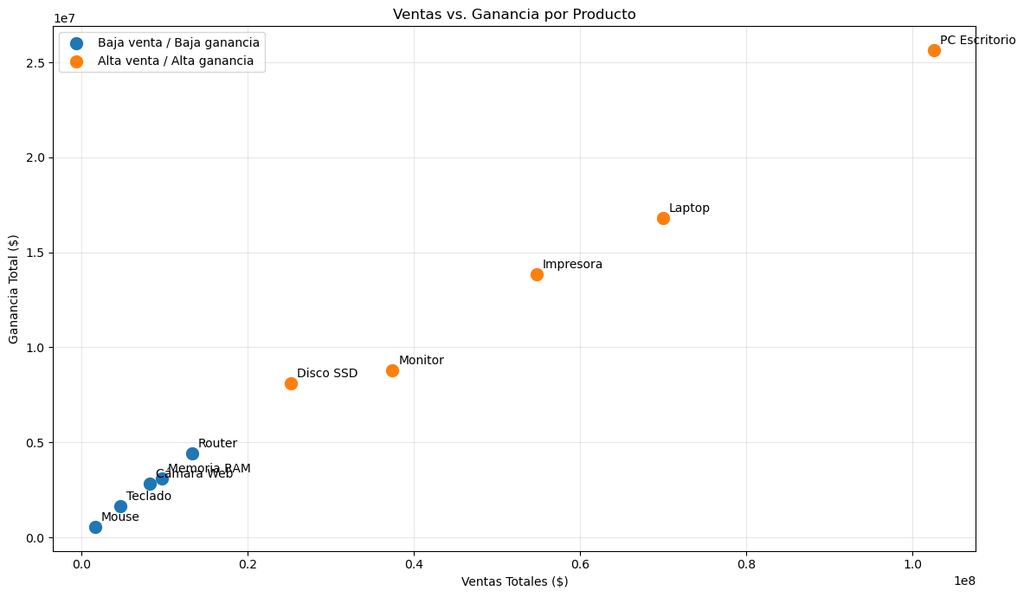

```python
plt.figure(figsize=(12, 7))

for segmento in analisis_producto["Segmento"].unique():
    datos = analisis_producto[
        analisis_producto["Segmento"] == segmento
    ]

    plt.scatter(
        datos["Ventas_Totales"],
        datos["Ganancia_Total"],
        label=segmento,
        s=100
    )

# Agregar nombres de los productos
for producto, fila in analisis_producto.iterrows():
    plt.annotate(
        producto,
        (fila["Ventas_Totales"], fila["Ganancia_Total"]),
        xytext=(5, 5),
        textcoords="offset points"
    )

plt.title("Ventas vs. Ganancia por Producto")
plt.xlabel("Ventas Totales ($)")
plt.ylabel("Ganancia Total ($)")
plt.legend()
plt.grid(True, alpha=0.3)

plt.tight_layout()
plt.show()
```

```python
import pandas as pd

print("📋 DATAFRAMES DISPONIBLES")
print("=" * 50)

dataframes = [
    (nombre, objeto)
    for nombre, objeto in list(globals().items())
    if isinstance(objeto, pd.DataFrame)
]

for nombre, objeto in dataframes:
    print(f"➡️ {nombre} | Filas: {objeto.shape[0]} | Columnas: {objeto.shape[1]}")
```

[output not shown]

```python
print("📊 COLUMNAS DE ANALISIS_PRODUCTO")
print("=" * 50)

print(analisis_producto.columns.tolist())

print("\n📋 DATOS DE ANALISIS_PRODUCTO")
print("=" * 50)

display(analisis_producto)
```

```
📊 COLUMNAS DE ANALISIS_PRODUCTO
==================================================
['Ventas_Totales', 'Ganancia_Total', 'Unidades_Vendidas', 'Margen_%', 'Segmento']

📋 DATOS DE ANALISIS_PRODUCTO
==================================================
```

| Producto | Ventas_Totales | Ganancia_Total | Unidades_Vendidas | Margen_% | Segmento |
| --- | --- | --- | --- | --- | --- |
| Cámara Web | 8160000 | 2805000 | 51 | 34.375000 | Baja venta / Baja ganancia |
| Disco SSD | 25200000 | 8100000 | 90 | 32.142857 | Alta venta / Alta ganancia |
| Impresora | 54750000 | 13870000 | 73 | 25.333333 | Alta venta / Alta ganancia |
| Laptop | 70000000 | 16800000 | 28 | 24.000000 | Alta venta / Alta ganancia |
| Memoria RAM | 9680000 | 3080000 | 44 | 31.818182 | Baja venta / Baja ganancia |
| Monitor | 37400000 | 8800000 | 44 | 23.529412 | Alta venta / Alta ganancia |
| Mouse | 1620000 | 540000 | 36 | 33.333333 | Baja venta / Baja ganancia |
| PC Escritorio | 102600000 | 25650000 | 57 | 25.000000 | Alta venta / Alta ganancia |
| Router | 13320000 | 4440000 | 74 | 33.333333 | Baja venta / Baja ganancia |
| Teclado | 4675000 | 1650000 | 55 | 35.294118 | Baja venta / Baja ganancia |

```python
ranking_ganancia = analisis_producto.sort_values(
    by="Ganancia_Total",
    ascending=False
)

print("🏆 RANKING DE PRODUCTOS POR GANANCIA")
print("=" * 50)

display(
    ranking_ganancia[
        ["Ganancia_Total", "Ventas_Totales", "Margen_%", "Segmento"]
    ]
)
```

```
🏆 RANKING DE PRODUCTOS POR GANANCIA
==================================================
```

| Producto | Ganancia_Total | Ventas_Totales | Margen_% | Segmento |
| --- | --- | --- | --- | --- |
| PC Escritorio | 25650000 | 102600000 | 25.000000 | Alta venta / Alta ganancia |
| Laptop | 16800000 | 70000000 | 24.000000 | Alta venta / Alta ganancia |
| Impresora | 13870000 | 54750000 | 25.333333 | Alta venta / Alta ganancia |
| Monitor | 8800000 | 37400000 | 23.529412 | Alta venta / Alta ganancia |
| Disco SSD | 8100000 | 25200000 | 32.142857 | Alta venta / Alta ganancia |
| Router | 4440000 | 13320000 | 33.333333 | Baja venta / Baja ganancia |
| Memoria RAM | 3080000 | 9680000 | 31.818182 | Baja venta / Baja ganancia |
| Cámara Web | 2805000 | 8160000 | 34.375000 | Baja venta / Baja ganancia |
| Teclado | 1650000 | 4675000 | 35.294118 | Baja venta / Baja ganancia |
| Mouse | 540000 | 1620000 | 33.333333 | Baja venta / Baja ganancia |

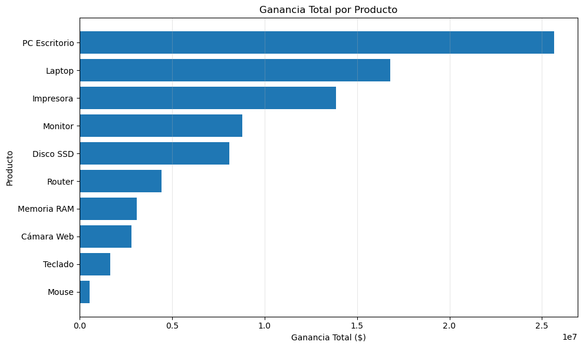

```python
import matplotlib.pyplot as plt

ranking_ganancia = analisis_producto.sort_values(
    by="Ganancia_Total",
    ascending=True
)

plt.figure(figsize=(10, 6))

plt.barh(
    ranking_ganancia.index,
    ranking_ganancia["Ganancia_Total"]
)

plt.title("Ganancia Total por Producto")
plt.xlabel("Ganancia Total ($)")
plt.ylabel("Producto")

plt.grid(axis="x", alpha=0.3)
plt.tight_layout()
plt.show()
```

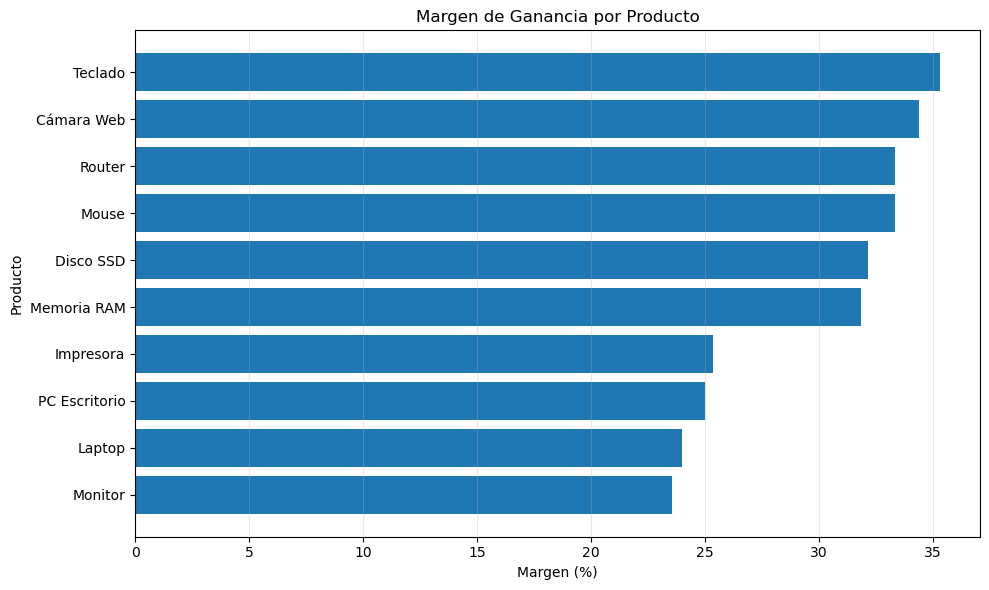

```python
margen_producto = analisis_producto.sort_values(
    by="Margen_%",
    ascending=True
)

plt.figure(figsize=(10, 6))

plt.barh(
    margen_producto.index,
    margen_producto["Margen_%"]
)

plt.title("Margen de Ganancia por Producto")
plt.xlabel("Margen (%)")
plt.ylabel("Producto")

plt.grid(axis="x", alpha=0.3)
plt.tight_layout()
plt.show()
```

```python
ranking_margen = analisis_producto.sort_values(
    by="Margen_%",
    ascending=False
)

print("📈 RANKING DE PRODUCTOS POR MARGEN")
print("=" * 50)

display(
    ranking_margen[
        ["Margen_%", "Ganancia_Total", "Ventas_Totales", "Segmento"]
    ]
)
```

```
📈 RANKING DE PRODUCTOS POR MARGEN
==================================================
```

| Producto | Margen_% | Ganancia_Total | Ventas_Totales | Segmento |
| --- | --- | --- | --- | --- |
| Teclado | 35.294118 | 1650000 | 4675000 | Baja venta / Baja ganancia |
| Cámara Web | 34.375000 | 2805000 | 8160000 | Baja venta / Baja ganancia |
| Mouse | 33.333333 | 540000 | 1620000 | Baja venta / Baja ganancia |
| Router | 33.333333 | 4440000 | 13320000 | Baja venta / Baja ganancia |
| Disco SSD | 32.142857 | 8100000 | 25200000 | Alta venta / Alta ganancia |
| Memoria RAM | 31.818182 | 3080000 | 9680000 | Baja venta / Baja ganancia |
| Impresora | 25.333333 | 13870000 | 54750000 | Alta venta / Alta ganancia |
| PC Escritorio | 25.000000 | 25650000 | 102600000 | Alta venta / Alta ganancia |
| Laptop | 24.000000 | 16800000 | 70000000 | Alta venta / Alta ganancia |
| Monitor | 23.529412 | 8800000 | 37400000 | Alta venta / Alta ganancia |

```python
print("🏙️ COLUMNAS DE ANALISIS_CIUDAD")
print("=" * 50)

print(analisis_ciudad.columns.tolist())

print("\n📋 DATOS DE ANALISIS_CIUDAD")
print("=" * 50)

display(analisis_ciudad)
```

```
🏙️ COLUMNAS DE ANALISIS_CIUDAD
==================================================
['Ventas_Totales', 'Ganancia_Total', 'Unidades_Vendidas', 'Transacciones', 'Margen_%']

📋 DATOS DE ANALISIS_CIUDAD
==================================================
```

| Ciudad | Ventas_Totales | Ganancia_Total | Unidades_Vendidas | Transacciones | Margen_% |
| --- | --- | --- | --- | --- | --- |
| Bogotá | 108565000 | 27885000 | 129 | 24 | 25.685073 |
| Barranquilla | 90625000 | 23515000 | 122 | 22 | 25.947586 |
| Cali | 70865000 | 18545000 | 127 | 22 | 26.169477 |
| Tunja | 33375000 | 8685000 | 89 | 17 | 26.022472 |
| Medellín | 23975000 | 7105000 | 85 | 15 | 29.635036 |

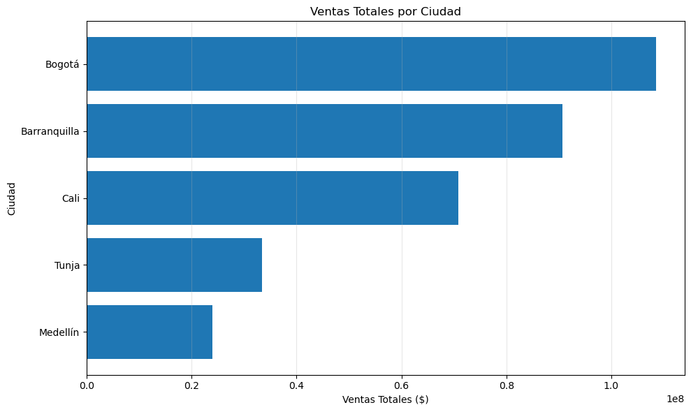

```python
ventas_ciudad = analisis_ciudad.sort_values(
    by="Ventas_Totales",
    ascending=True
)

plt.figure(figsize=(10, 6))

plt.barh(
    ventas_ciudad.index,
    ventas_ciudad["Ventas_Totales"]
)

plt.title("Ventas Totales por Ciudad")
plt.xlabel("Ventas Totales ($)")
plt.ylabel("Ciudad")

plt.grid(axis="x", alpha=0.3)
plt.tight_layout()
plt.show()
```

```python
ranking_ganancia_ciudad = analisis_ciudad.sort_values(
    by="Ganancia_Total",
    ascending=False
)

print("💰 RANKING DE CIUDADES POR GANANCIA")
print("=" * 50)

display(
    ranking_ganancia_ciudad[
        ["Ganancia_Total", "Ventas_Totales", "Margen_%", "Transacciones"]
    ]
)
```

```
💰 RANKING DE CIUDADES POR GANANCIA
==================================================
```

| Ciudad | Ganancia_Total | Ventas_Totales | Margen_% | Transacciones |
| --- | --- | --- | --- | --- |
| Bogotá | 27885000 | 108565000 | 25.685073 | 24 |
| Barranquilla | 23515000 | 90625000 | 25.947586 | 22 |
| Cali | 18545000 | 70865000 | 26.169477 | 22 |
| Tunja | 8685000 | 33375000 | 26.022472 | 17 |
| Medellín | 7105000 | 23975000 | 29.635036 | 15 |

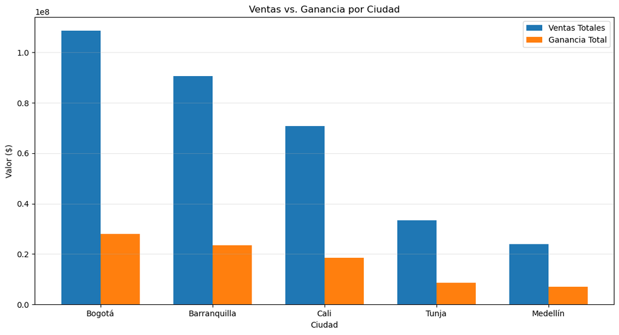

```python
import numpy as np
import matplotlib.pyplot as plt

ciudades = analisis_ciudad.index
ventas = analisis_ciudad["Ventas_Totales"]
ganancias = analisis_ciudad["Ganancia_Total"]

x = np.arange(len(ciudades))
ancho = 0.35

plt.figure(figsize=(11, 6))

plt.bar(
    x - ancho/2,
    ventas,
    width=ancho,
    label="Ventas Totales"
)

plt.bar(
    x + ancho/2,
    ganancias,
    width=ancho,
    label="Ganancia Total"
)

plt.title("Ventas vs. Ganancia por Ciudad")
plt.xlabel("Ciudad")
plt.ylabel("Valor ($)")
plt.xticks(x, ciudades)
plt.legend()

plt.grid(axis="y", alpha=0.3)
plt.tight_layout()
plt.show()
```

```python
print("👤 COLUMNAS DE ANALISIS_VENDEDOR")
print("=" * 50)

print(analisis_vendedor.columns.tolist())

print("\n📋 DATOS DE ANALISIS_VENDEDOR")
print("=" * 50)

display(analisis_vendedor)
```

```
👤 COLUMNAS DE ANALISIS_VENDEDOR
==================================================
['Ventas_Totales', 'Ganancia_Total', 'Unidades_Vendidas', 'Transacciones', 'Ticket_Promedio', 'Margen_%']

📋 DATOS DE ANALISIS_VENDEDOR
==================================================
```

| Vendedor | Ventas_Totales | Ganancia_Total | Unidades_Vendidas | Transacciones | Ticket_Promedio | Margen_% |
| --- | --- | --- | --- | --- | --- | --- |
| Camila | 110555000 | 28120000 | 150 | 25 | 4.422200e+06 | 25.435304 |
| Andrés | 92195000 | 23900000 | 132 | 25 | 3.687800e+06 | 25.923315 |
| Carlos | 63510000 | 17160000 | 140 | 26 | 2.442692e+06 | 27.019367 |
| Laura | 33070000 | 8870000 | 61 | 10 | 3.307000e+06 | 26.821893 |
| Miguel | 28075000 | 7685000 | 69 | 14 | 2.005357e+06 | 27.373108 |

```python
ranking_vendedores = analisis_vendedor.sort_values(
    by="Ventas_Totales",
    ascending=False
)

print("🏆 RANKING DE VENDEDORES POR VENTAS")
print("=" * 50)

display(
    ranking_vendedores[
        ["Ventas_Totales", "Ganancia_Total", "Unidades_Vendidas",
         "Transacciones", "Ticket_Promedio", "Margen_%"]
    ]
)
```

```
🏆 RANKING DE VENDEDORES POR VENTAS
==================================================
```

| Vendedor | Ventas_Totales | Ganancia_Total | Unidades_Vendidas | Transacciones | Ticket_Promedio | Margen_% |
| --- | --- | --- | --- | --- | --- | --- |
| Camila | 110555000 | 28120000 | 150 | 25 | 4.422200e+06 | 25.435304 |
| Andrés | 92195000 | 23900000 | 132 | 25 | 3.687800e+06 | 25.923315 |
| Carlos | 63510000 | 17160000 | 140 | 26 | 2.442692e+06 | 27.019367 |
| Laura | 33070000 | 8870000 | 61 | 10 | 3.307000e+06 | 26.821893 |
| Miguel | 28075000 | 7685000 | 69 | 14 | 2.005357e+06 | 27.373108 |

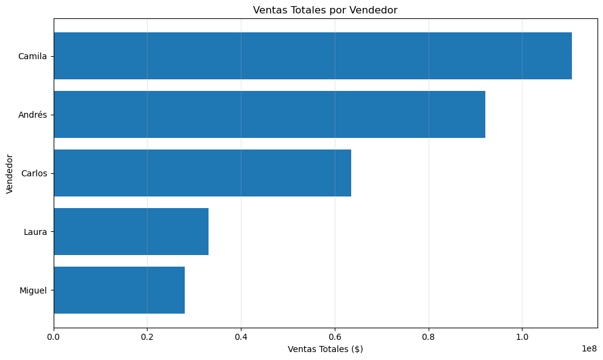

```python
ventas_vendedor = analisis_vendedor.sort_values(
    by="Ventas_Totales",
    ascending=True
)

plt.figure(figsize=(10, 6))

plt.barh(
    ventas_vendedor.index,
    ventas_vendedor["Ventas_Totales"]
)

plt.title("Ventas Totales por Vendedor")
plt.xlabel("Ventas Totales ($)")
plt.ylabel("Vendedor")

plt.grid(axis="x", alpha=0.3)
plt.tight_layout()
plt.show()
```

```python
ranking_ganancia_vendedor = analisis_vendedor.sort_values(
    by="Ganancia_Total",
    ascending=False
)

print("💰 RANKING DE VENDEDORES POR GANANCIA")
print("=" * 50)

display(
    ranking_ganancia_vendedor[
        ["Ganancia_Total", "Ventas_Totales", "Ticket_Promedio", "Margen_%"]
    ]
)
```

```
💰 RANKING DE VENDEDORES POR GANANCIA
==================================================
```

| Vendedor | Ganancia_Total | Ventas_Totales | Ticket_Promedio | Margen_% |
| --- | --- | --- | --- | --- |
| Camila | 28120000 | 110555000 | 4.422200e+06 | 25.435304 |
| Andrés | 23900000 | 92195000 | 3.687800e+06 | 25.923315 |
| Carlos | 17160000 | 63510000 | 2.442692e+06 | 27.019367 |
| Laura | 8870000 | 33070000 | 3.307000e+06 | 26.821893 |
| Miguel | 7685000 | 28075000 | 2.005357e+06 | 27.373108 |

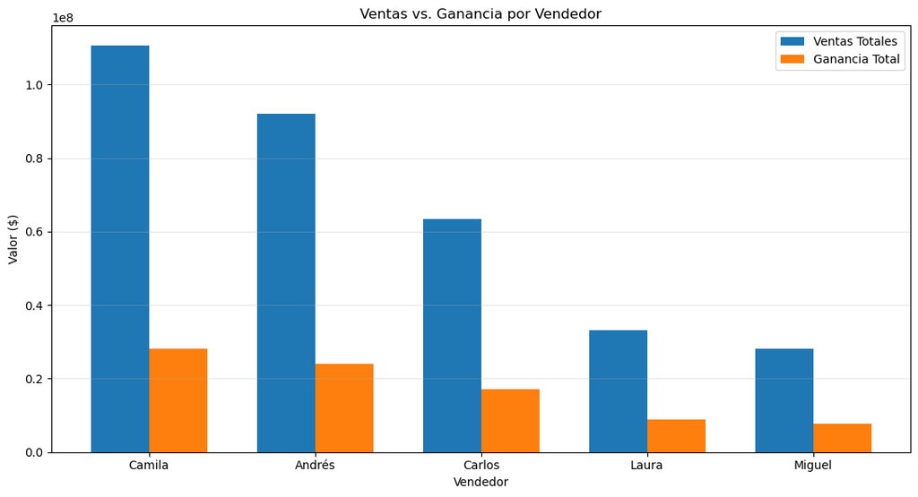

```python
vendedores = analisis_vendedor.index
ventas = analisis_vendedor["Ventas_Totales"]
ganancias = analisis_vendedor["Ganancia_Total"]

x = np.arange(len(vendedores))
ancho = 0.35

plt.figure(figsize=(11, 6))

plt.bar(
    x - ancho/2,
    ventas,
    width=ancho,
    label="Ventas Totales"
)

plt.bar(
    x + ancho/2,
    ganancias,
    width=ancho,
    label="Ganancia Total"
)

plt.title("Ventas vs. Ganancia por Vendedor")
plt.xlabel("Vendedor")
plt.ylabel("Valor ($)")
plt.xticks(x, vendedores)
plt.legend()

plt.grid(axis="y", alpha=0.3)
plt.tight_layout()
plt.show()
```

```python
print("💳 COLUMNAS DE ANALISIS_PAGO")
print("=" * 50)

print(analisis_pago.columns.tolist())

print("\n📋 DATOS DE ANALISIS_PAGO")
print("=" * 50)

display(analisis_pago)
```

```
💳 COLUMNAS DE ANALISIS_PAGO
==================================================
['Ventas_Totales', 'Ganancia_Total', 'Transacciones', 'Unidades_Vendidas', 'Ticket_Promedio']

📋 DATOS DE ANALISIS_PAGO
==================================================
```

| Metodo_Pago | Ventas_Totales | Ganancia_Total | Transacciones | Unidades_Vendidas | Ticket_Promedio |
| --- | --- | --- | --- | --- | --- |
| Tarjeta | 132210000 | 33685000 | 31 | 167 | 4.264839e+06 |
| Nequi | 97985000 | 25495000 | 23 | 134 | 4.260217e+06 |
| Transferencia | 54340000 | 14765000 | 25 | 147 | 2.173600e+06 |
| Efectivo | 42870000 | 11790000 | 21 | 104 | 2.041429e+06 |

```python
ranking_pago = analisis_pago.sort_values(
    by="Ventas_Totales",
    ascending=False
)

print("💳 RANKING DE MÉTODOS DE PAGO POR VENTAS")
print("=" * 50)

display(
    ranking_pago[
        ["Ventas_Totales", "Ganancia_Total",
         "Transacciones", "Unidades_Vendidas", "Ticket_Promedio"]
    ]
)
```

```
💳 RANKING DE MÉTODOS DE PAGO POR VENTAS
==================================================
```

| Metodo_Pago | Ventas_Totales | Ganancia_Total | Transacciones | Unidades_Vendidas | Ticket_Promedio |
| --- | --- | --- | --- | --- | --- |
| Tarjeta | 132210000 | 33685000 | 31 | 167 | 4.264839e+06 |
| Nequi | 97985000 | 25495000 | 23 | 134 | 4.260217e+06 |
| Transferencia | 54340000 | 14765000 | 25 | 147 | 2.173600e+06 |
| Efectivo | 42870000 | 11790000 | 21 | 104 | 2.041429e+06 |

[figure not shown]

```python
ventas_pago = analisis_pago.sort_values(
    by="Ventas_Totales",
    ascending=True
)

plt.figure(figsize=(10, 6))

plt.barh(
    ventas_pago.index,
    ventas_pago["Ventas_Totales"]
)

plt.title("Ventas Totales por Método de Pago")
plt.xlabel("Ventas Totales ($)")
plt.ylabel("Método de Pago")

plt.grid(axis="x", alpha=0.3)
plt.tight_layout()
plt.show()
```

```python
participacion_pago = analisis_pago.copy()

participacion_pago["Participacion_%"] = (
    participacion_pago["Ventas_Totales"]
    / participacion_pago["Ventas_Totales"].sum()
    * 100
)

participacion_pago = participacion_pago.sort_values(
    by="Participacion_%",
    ascending=False
)

print("💳 PARTICIPACIÓN DE MÉTODOS DE PAGO")
print("=" * 50)

display(
    participacion_pago[
        ["Ventas_Totales", "Participacion_%", "Transacciones", "Ticket_Promedio"]
    ]
)
```

```
💳 PARTICIPACIÓN DE MÉTODOS DE PAGO
==================================================
```

| Metodo_Pago | Ventas_Totales | Participacion_% | Transacciones | Ticket_Promedio |
| --- | --- | --- | --- | --- |
| Tarjeta | 132210000 | 40.381179 | 31 | 4.264839e+06 |
| Nequi | 97985000 | 29.927765 | 23 | 4.260217e+06 |
| Transferencia | 54340000 | 16.597181 | 25 | 2.173600e+06 |
| Efectivo | 42870000 | 13.093875 | 21 | 2.041429e+06 |

```python
print("📋 COLUMNAS DE DF_VENTAS")
print("=" * 60)

print(df_ventas.columns.tolist())
```

```
📋 COLUMNAS DE DF_VENTAS
============================================================
['Fecha', 'Producto', 'Categoria', 'Ciudad', 'Vendedor', 'Metodo_Pago', 'Cantidad', 'Precio', 'Costo', 'Venta_Total', 'Costo_Total', 'Ganancia', 'Margen_%', 'Mes']
```

```python
print("📊 RESUMEN GENERAL - PROYECTO 2")
print("=" * 60)
ventas_totales = df_ventas["Venta_Total"].sum()

ganancia_total = df_ventas["Ganancia"].sum()

unidades_totales = df_ventas["Cantidad"].sum()

transacciones_totales = len(df_ventas)
margen_general = (ganancia_total / ventas_totales) * 100

print(f"💰 Ventas Totales: ${ventas_totales:,.0f}")
print(f"📈 Ganancia Total: ${ganancia_total:,.0f}")
print(f"📦 Unidades Vendidas: {unidades_totales:,.0f}")
print(f"🧾 Transacciones: {transacciones_totales:,.0f}")
print(f"📊 Margen General: {margen_general:.2f}%")
```

```
📊 RESUMEN GENERAL - PROYECTO 2
============================================================
💰 Ventas Totales: $327,405,000
📈 Ganancia Total: $85,735,000
📦 Unidades Vendidas: 552
🧾 Transacciones: 100
📊 Margen General: 26.19%
```

```python
print("🏆 CONCLUSIONES PRINCIPALES - PROYECTO 2")
print("=" * 60)

producto_ganancia = analisis_producto["Ganancia_Total"].idxmax()
ganancia_producto = analisis_producto.loc[producto_ganancia, "Ganancia_Total"]

ciudad_ventas = analisis_ciudad["Ventas_Totales"].idxmax()
ventas_ciudad = analisis_ciudad.loc[ciudad_ventas, "Ventas_Totales"]

vendedor_ventas = analisis_vendedor["Ventas_Totales"].idxmax()
ventas_vendedor = analisis_vendedor.loc[vendedor_ventas, "Ventas_Totales"]

metodo_pago = analisis_pago["Transacciones"].idxmax()
transacciones_pago = analisis_pago.loc[metodo_pago, "Transacciones"]

producto_margen = analisis_producto["Margen_%"].idxmax()
margen_producto = analisis_producto.loc[producto_margen, "Margen_%"]

print(f"🥇 Producto más rentable: {producto_ganancia}")
print(f"   Ganancia: ${ganancia_producto:,.0f}")
print()

print(f"🏙️ Ciudad con mayores ventas: {ciudad_ventas}")
print(f"   Ventas: ${ventas_ciudad:,.0f}")
print()

print(f"👤 Vendedor con mayores ventas: {vendedor_ventas}")
print(f"   Ventas: ${ventas_vendedor:,.0f}")
print()

print(f"💳 Método de pago más utilizado: {metodo_pago}")
print(f"   Transacciones: {transacciones_pago}")
print()

print(f"📊 Producto con mayor margen: {producto_margen}")
print(f"   Margen: {margen_producto:.2f}%")
```

```
🏆 CONCLUSIONES PRINCIPALES - PROYECTO 2
============================================================
🥇 Producto más rentable: PC Escritorio
   Ganancia: $25,650,000

🏙️ Ciudad con mayores ventas: Bogotá
   Ventas: $108,565,000

👤 Vendedor con mayores ventas: Camila
   Ventas: $110,555,000

💳 Método de pago más utilizado: Tarjeta
   Transacciones: 31

📊 Producto con mayor margen: Teclado
   Margen: 35.29%
```

```python
print("📋 ANÁLISIS EJECUTIVO - PROYECTO 2")
print("=" * 65)

print("\n💰 DESEMPEÑO GENERAL")
print(f"Las ventas totales fueron de ${ventas_totales:,.0f},")
print(f"con una ganancia de ${ganancia_total:,.0f} y un margen general de {margen_general:.2f}%.")

print("\n🏆 PRODUCTOS")
print(f"El PC Escritorio fue el producto con mayor ganancia,")
print(f"generando ${ganancia_producto:,.0f}.")
print(f"El Teclado presentó el mayor margen de rentabilidad con {margen_producto:.2f}%.")

print("\n🏙️ CIUDADES")
print(f"Bogotá fue la ciudad con mayores ventas,")
print(f"alcanzando ${ventas_ciudad:,.0f}.")

print("\n👤 VENDEDORES")
print(f"Camila fue la vendedora con mayores ventas,")
print(f"con un total de ${ventas_vendedor:,.0f}.")

print("\n💳 MÉTODOS DE PAGO")
print(f"Tarjeta fue el método de pago más utilizado,")
print(f"con {transacciones_pago} transacciones.")

print("\n💡 RECOMENDACIONES")
print("1. Mantener y fortalecer la venta de productos de alta rentabilidad.")
print("2. Analizar las estrategias comerciales utilizadas en Bogotá.")
print("3. Identificar las buenas prácticas del vendedor con mayor desempeño.")
print("4. Mantener opciones de pago con tarjeta para facilitar las compras.")
print("5. Promover productos con márgenes altos como el Teclado.")
```

```
📋 ANÁLISIS EJECUTIVO - PROYECTO 2
=================================================================

💰 DESEMPEÑO GENERAL
Las ventas totales fueron de $327,405,000,
con una ganancia de $85,735,000 y un margen general de 26.19%.

🏆 PRODUCTOS
El PC Escritorio fue el producto con mayor ganancia,
generando $25,650,000.
El Teclado presentó el mayor margen de rentabilidad con 35.29%.

🏙️ CIUDADES
Bogotá fue la ciudad con mayores ventas,
alcanzando $108,565,000.

👤 VENDEDORES
Camila fue la vendedora con mayores ventas,
con un total de $110,555,000.

💳 MÉTODOS DE PAGO
Tarjeta fue el método de pago más utilizado,
con 31 transacciones.

💡 RECOMENDACIONES
1. Mantener y fortalecer la venta de productos de alta rentabilidad.
2. Analizar las estrategias comerciales utilizadas en Bogotá.
3. Identificar las buenas prácticas del vendedor con mayor desempeño.
4. Mantener opciones de pago con tarjeta para facilitar las compras.
5. Promover productos con márgenes altos como el Teclado.
```

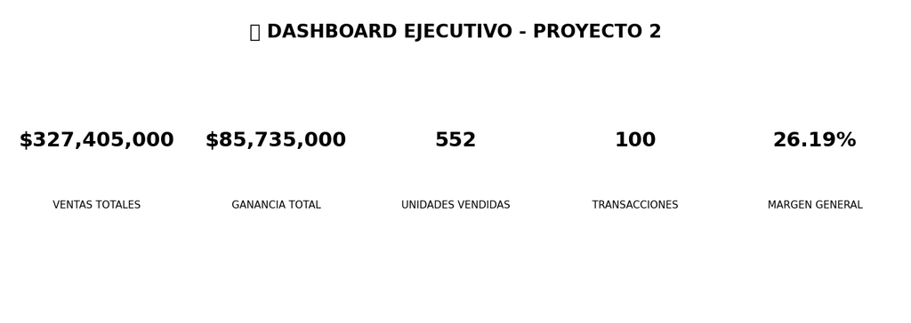

```python
import matplotlib.pyplot as plt

fig, ax = plt.subplots(figsize=(14, 5))

ax.axis("off")
ax.text(
    0.5, 0.90,
    "📊 DASHBOARD EJECUTIVO - PROYECTO 2",
    ha="center",
    fontsize=20,
    fontweight="bold"
)
ax.text(
    0.10, 0.55,
    f"${ventas_totales:,.0f}",
    ha="center",
    fontsize=22,
    fontweight="bold"
)
ax.text(
    0.10, 0.35,
    "VENTAS TOTALES",
    ha="center",
    fontsize=11
)

ax.text(
    0.30, 0.55,
    f"${ganancia_total:,.0f}",
    ha="center",
    fontsize=22,
    fontweight="bold"
)
ax.text(
    0.30, 0.35,
    "GANANCIA TOTAL",
    ha="center",
    fontsize=11
)

ax.text(
    0.50, 0.55,
    f"{unidades_totales:,.0f}",
    ha="center",
    fontsize=22,
    fontweight="bold"
)
ax.text(
    0.50, 0.35,
    "UNIDADES VENDIDAS",
    ha="center",
    fontsize=11
)

ax.text(
    0.70, 0.55,
    f"{transacciones_totales:,.0f}",
    ha="center",
    fontsize=22,
    fontweight="bold"
)
ax.text(
    0.70, 0.35,
    "TRANSACCIONES",
    ha="center",
    fontsize=11
)

ax.text(
    0.90, 0.55,
    f"{margen_general:.2f}%",
    ha="center",
    fontsize=22,
    fontweight="bold"
)
ax.text(
    0.90, 0.35,
    "MARGEN GENERAL",
    ha="center",
    fontsize=11
)

plt.tight_layout()
plt.show()
```

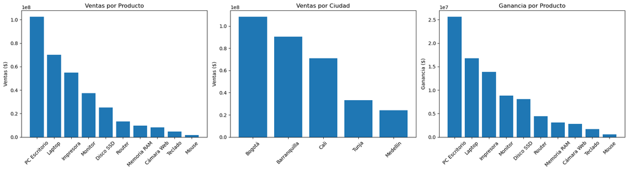

```python
fig, axes = plt.subplots(1, 3, figsize=(18, 5))

ventas_producto = df_ventas.groupby("Producto")["Venta_Total"].sum().sort_values(ascending=False)

axes[0].bar(ventas_producto.index, ventas_producto.values)
axes[0].set_title("Ventas por Producto")
axes[0].set_ylabel("Ventas ($)")
axes[0].tick_params(axis="x", rotation=45)

ventas_ciudad = df_ventas.groupby("Ciudad")["Venta_Total"].sum().sort_values(ascending=False)

axes[1].bar(ventas_ciudad.index, ventas_ciudad.values)
axes[1].set_title("Ventas por Ciudad")
axes[1].set_ylabel("Ventas ($)")
axes[1].tick_params(axis="x", rotation=45)

ganancia_producto = df_ventas.groupby("Producto")["Ganancia"].sum().sort_values(ascending=False)

axes[2].bar(ganancia_producto.index, ganancia_producto.values)
axes[2].set_title("Ganancia por Producto")
axes[2].set_ylabel("Ganancia ($)")
axes[2].tick_params(axis="x", rotation=45)

plt.tight_layout()
plt.show()
```

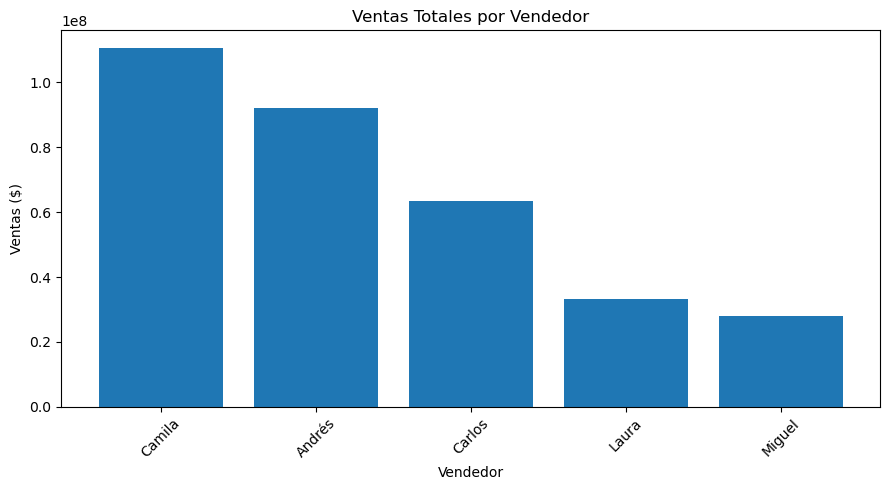

```python
ventas_vendedor = (
    df_ventas.groupby("Vendedor")["Venta_Total"]
    .sum()
    .sort_values(ascending=False)
)

plt.figure(figsize=(9, 5))

plt.bar(ventas_vendedor.index, ventas_vendedor.values)

plt.title("Ventas Totales por Vendedor")
plt.xlabel("Vendedor")
plt.ylabel("Ventas ($)")
plt.xticks(rotation=45)

plt.tight_layout()
plt.show()
```

[figure not shown]

```python
transacciones_pago = (
    df_ventas.groupby("Metodo_Pago")
    .size()
    .sort_values(ascending=False)
)

plt.figure(figsize=(8, 5))

plt.bar(transacciones_pago.index, transacciones_pago.values)

plt.title("Transacciones por Método de Pago")
plt.xlabel("Método de Pago")
plt.ylabel("Número de Transacciones")

plt.tight_layout()
plt.show()
```

```python
print("=" * 60)
print("📊 CONCLUSIONES FINALES - PROYECTO 2")
print("=" * 60)

print("\n1. DESEMPEÑO GENERAL")
print(f"Las ventas totales fueron de ${ventas_totales:,.0f}.")
print(f"La ganancia total alcanzó ${ganancia_total:,.0f}.")
print(f"El margen general fue de {margen_general:.2f}%.")

print("\n2. PRODUCTO MÁS RENTABLE")

print("El margen general fue de {:.1f}%".format(margen_general))
print(f"Ganancia generada: ${ganancia_producto.iloc[0]:.0f}.")

print("\n3. CIUDAD CON MAYORES VENTAS")
print(f"La ciudad con mayores ventas fue: {ciudad_ventas}.")
print(f"Ventas generadas: ${ventas_ciudad.iloc[0]:.0f}.")

print("\n4. MEJOR VENDEDOR")
print(f"El vendedor con mayores ventas fue: {vendedor_ventas}.")
print(f"Ventas generadas: {ventas_vendedor}.")

pago_mas_usado = analisis_pago["Transacciones"].idxmax()
cantidad_transacciones = analisis_pago.loc[pago_mas_usado, "Transacciones"]


print("\n5. MÉTODO DE PAGO MÁS UTILIZADO")
print(f"El método de pago más utilizado fue: {metodo_pago}.")
print(f"Número de transacciones: {transacciones_pago.loc[metodo_pago]}.")

print("\n" + "=" * 60)
print("✅ ANÁLISIS COMPLETADO")
print("=" * 60)
```

[output not shown]

```python
print(type(ganancia_producto))
print(type(ventas_ciudad))
print(type(ventas_vendedor))
```

```
<class 'pandas.core.series.Series'>
<class 'pandas.core.series.Series'>
<class 'pandas.core.series.Series'>
```

```python
print("=" * 60)
print("📊 CONCLUSIONES FINALES - PROYECTO 2")
print("=" * 60)

margen_general = ganancia_total / ventas_totales

print("\n1. DESEMPEÑO GENERAL")
print(f"Las ventas totales fueron de ${ventas_totales:,.0f}.")
print(f"La ganancia total alcanzó ${ganancia_total:,.0f}.")
print(f"El margen general fue de {margen_general:.2%}.")



print("\n2. PRODUCTO MÁS RENTABLE")
print(f"El producto con mayor ganancia fue: {ganancia_producto.idxmax()}.")
print(f"La ganancia generada fue de ${ganancia_producto.max():,.0f}.")

print("\n3. CIUDAD CON MAYORES VENTAS")
ciudad_mayores_ventas = ventas_ciudad.idxmax()
valor_mayores_ventas = ventas_ciudad.max()

print(f"La ciudad con mayores ventas fue: {ciudad_mayores_ventas}.")
print(f"Las ventas generadas fueron de ${valor_mayores_ventas:,.0f}.")



print("\n4. MEJOR VENDEDOR")
mejor_vendedor = ventas_vendedor.idxmax()
valor_mejor_vendedor = ventas_vendedor.max()

print(f"El vendedor con mayores ventas fue: {mejor_vendedor}.")
print(f"Las ventas generadas fueron de ${valor_mejor_vendedor:,.0f}.")


print("\n5. MÉTODO DE PAGO MÁS UTILIZADO")
pago_mas_usado = analisis_pago["Transacciones"].idxmax()
cantidad_transacciones = analisis_pago["Transacciones"].max()

print(f"El método de pago más utilizado fue: {pago_mas_usado}.")
print(f"Número de transacciones: {cantidad_transacciones:,.0f}.")

print("\n" + "=" * 60)
print("✅ ANÁLISIS COMPLETADO")
print("=" * 60)
```

```
============================================================
📊 CONCLUSIONES FINALES - PROYECTO 2
============================================================

1. DESEMPEÑO GENERAL
Las ventas totales fueron de $327,405,000.
La ganancia total alcanzó $85,735,000.
El margen general fue de 26.19%.

2. PRODUCTO MÁS RENTABLE
El producto con mayor ganancia fue: PC Escritorio.
La ganancia generada fue de $25,650,000.

3. CIUDAD CON MAYORES VENTAS
La ciudad con mayores ventas fue: Bogotá.
Las ventas generadas fueron de $108,565,000.

4. MEJOR VENDEDOR
El vendedor con mayores ventas fue: Camila.
Las ventas generadas fueron de $110,555,000.

5. MÉTODO DE PAGO MÁS UTILIZADO
El método de pago más utilizado fue: Tarjeta.
Número de transacciones: 31.

============================================================
✅ ANÁLISIS COMPLETADO
============================================================
```

```python
print(type(ventas_ciudad))
print(type(ventas_vendedor))
```

```
<class 'pandas.core.series.Series'>
<class 'pandas.core.series.Series'>
```

```python
margen_general_correcto = ganancia_total / ventas_totales

print(f"Ventas totales: ${ventas_totales:,.0f}")
print(f"Ganancia total: ${ganancia_total:,.0f}")
print(f"Margen general correcto: {margen_general_correcto:.2%}")
```

```
Ventas totales: $327,405,000
Ganancia total: $85,735,000
Margen general correcto: 26.19%
```

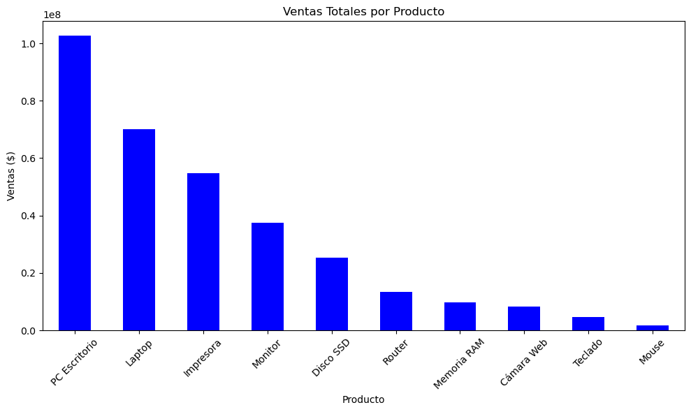

```python
import matplotlib.pyplot as plt


ventas_producto = df_ventas.groupby("Producto")["Venta_Total"].sum().sort_values(ascending=False)


plt.figure(figsize=(10, 6))
ventas_producto.plot(kind="bar", color="blue")

plt.title("Ventas Totales por Producto")
plt.xlabel("Producto")
plt.ylabel("Ventas ($)")
plt.xticks(rotation=45)
plt.tight_layout()
plt.show()
```

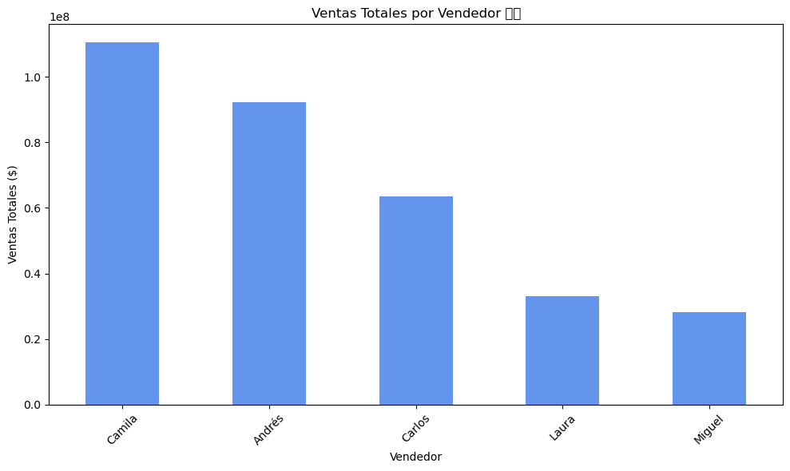

```python
ventas_vendedor = df_ventas.groupby('Vendedor')['Venta_Total'].sum().sort_values(ascending=False)

plt.figure(figsize=(10, 6))
ventas_vendedor.plot(kind='bar', color='cornflowerblue')


plt.title('Ventas Totales por Vendedor 👤📊')
plt.xlabel('Vendedor')
plt.ylabel('Ventas Totales ($)')
plt.xticks(rotation=45)
plt.tight_layout()
plt.show()
```